# The m-format Constellation User Manual

## `ms split`

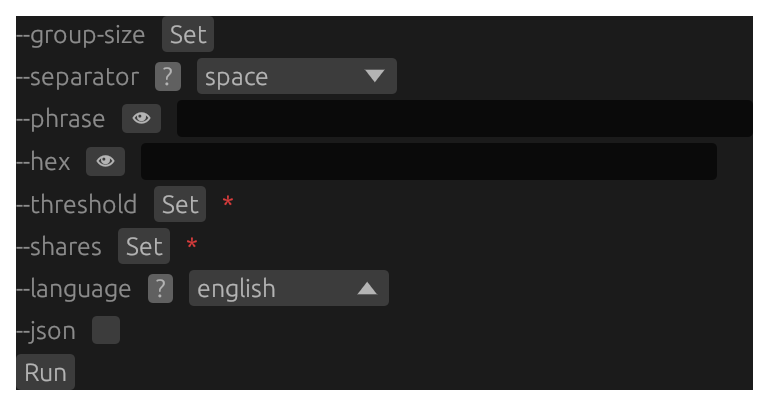

ms split — GUI form screenshot (dark theme, 2x)

Structural render of the `ms split` form — every flag and positional with its control kind and on-load default value (secret fields masked).

```
[ ms > split ]
  --group-size  number  -> <unset>
  --separator   dropdown[space,hyphen,comma]  -> space
  --phrase      text  (secret) -> <masked> [reveal]
  --hex         text  (secret) -> <masked> [reveal]
  --threshold   number  (required) -> <unset>
  --shares      number  (required) -> <unset>
  --language    dropdown[english,japanese,korean,spanish,chinese-simplified,chinese-traditional,french,italian,czech,portuguese]  -> english
  --json        checkbox  -> [ ] off
  [ Run ]
```

## `ms vectors`

Structural render of the `ms vectors` form — every flag and positional with its control kind and on-load default value (secret fields masked).

```
[ ms > vectors ]
  --pretty  checkbox  -> [ ] off
  [ Run ]
```

## `ms verify`

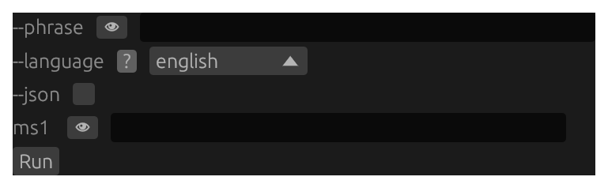

ms verify — GUI form screenshot (dark theme, 2x)

Structural render of the `ms verify` form — every flag and positional with its control kind and on-load default value (secret fields masked).

```
[ ms > verify ]
  --phrase    text  (secret) -> <masked> [reveal]
  --language  dropdown[english,japanese,korean,spanish,chinese-simplified,chinese-traditional,french,italian,czech,portuguese]  -> english
  --json      checkbox  -> [ ] off
  ms1         positional  (secret) -> <masked> [reveal]
  [ Run ]
```

# `mk` GUI forms

Screenshots and structural form renders for all 9 subcommands on the **`mk`** tab. See the GUI Forms reference overview for how to read a screenshot and a render and what `<masked>`, `(required)`, and `[disabled]` mean. Each form’s prose, per-flag reference, and worked example live in its own subcommand chapter, reached from the `> **GUI form:**` cross-link there.

## `mk address`

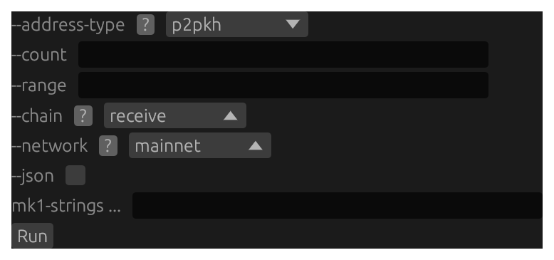

mk address — GUI form screenshot (dark theme, 2x)

Structural render of the `mk address` form — every flag and positional with its control kind and on-load default value (secret fields masked).

```
[ mk > address ]
  --address-type  dropdown[p2pkh,p2sh-p2wpkh,p2wpkh,p2tr]  -> p2pkh
  --count         text  -> <empty>
  --range         text  -> <empty>
  --chain         dropdown[receive,change,both]  -> receive
  --network       dropdown[mainnet,testnet,signet,regtest]  -> mainnet
  --json          checkbox  -> [ ] off
  mk1-strings     positional...  -> <empty>
  [ Run ]
```

## `mk decode`

Structural render of the `mk decode` form — every flag and positional with its control kind and on-load default value (secret fields masked).

```
[ mk > decode ]
  --json       checkbox  -> [ ] off
  mk1-strings  positional...  -> <empty>
  [ Run ]
```

## `mk derive`

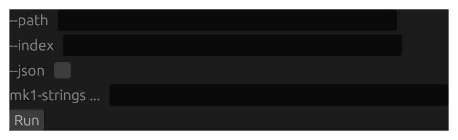

mk derive — GUI form screenshot (dark theme, 2x)

Structural render of the `mk derive` form — every flag and positional with its control kind and on-load default value (secret fields masked).

```
[ mk > derive ]
  --path       text  -> <empty>
  --index      text  -> <empty>
  --json       checkbox  -> [ ] off
  mk1-strings  positional...  -> <empty>
  [ Run ]
```

## `mk encode`

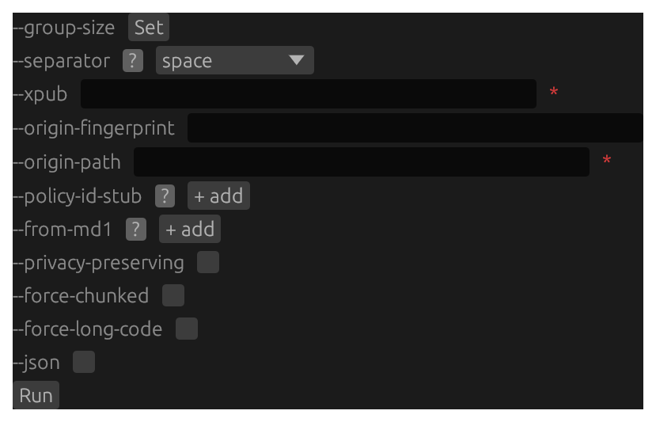

mk encode — GUI form screenshot (dark theme, 2x)

Structural render of the `mk encode` form — every flag and positional with its control kind and on-load default value (secret fields masked).

```
[ mk > encode ]
  --group-size          number  -> <unset>
  --separator           dropdown[space,hyphen,comma]  -> space
  --xpub                text  (required) -> <empty>
  --origin-fingerprint  text  -> <empty>
  --origin-path         text  (required) -> <empty>
  --policy-id-stub      text  (repeating) -> <empty>
  --from-md1            text  (repeating) -> <empty>
  --privacy-preserving  checkbox  -> [ ] off
  --force-chunked       checkbox  -> [ ] off
  --force-long-code     checkbox  -> [ ] off
  --json                checkbox  -> [ ] off
  [ Run ]
```

## `mk gen-man`

Structural render of the `mk gen-man` form — every flag and positional with its control kind and on-load default value (secret fields masked).

```
[ mk > gen-man ]
  --out  path  (required) -> <empty>
  [ Run ]
```

## `mk inspect`

Structural render of the `mk inspect` form — every flag and positional with its control kind and on-load default value (secret fields masked).

```
[ mk > inspect ]
  --json       checkbox  -> [ ] off
  mk1-strings  positional...  -> <empty>
  [ Run ]
```

## `mk repair`

Structural render of the `mk repair` form — every flag and positional with its control kind and on-load default value (secret fields masked).

```
[ mk > repair ]
  --json       checkbox  -> [ ] off
  mk1-strings  positional...  -> <empty>
  [ Run ]
```

## `mk vectors`

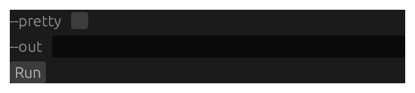

mk vectors — GUI form screenshot (dark theme, 2x)

Structural render of the `mk vectors` form — every flag and positional with its control kind and on-load default value (secret fields masked).

```
[ mk > vectors ]
  --pretty  checkbox  -> [ ] off
  --out     path  -> <empty>
  [ Run ]
```

## `mk verify`

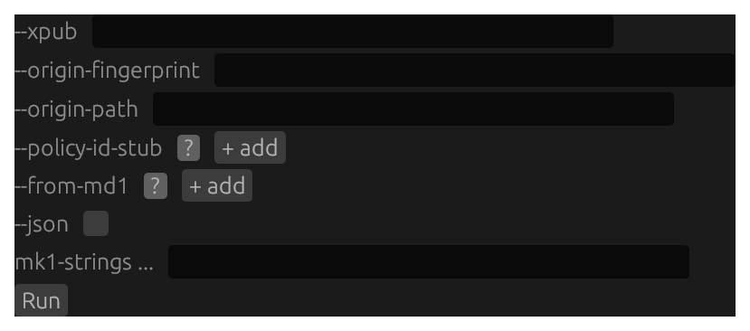

mk verify — GUI form screenshot (dark theme, 2x)

Structural render of the `mk verify` form — every flag and positional with its control kind and on-load default value (secret fields masked).

```
[ mk > verify ]
  --xpub                text  -> <empty>
  --origin-fingerprint  text  -> <empty>
  --origin-path         text  -> <empty>
  --policy-id-stub      text  (repeating) -> <empty>
  --from-md1            text  (repeating) -> <empty>
  --json                checkbox  -> [ ] off
  mk1-strings           positional...  -> <empty>
  [ Run ]
```

# Troubleshooting

Operational troubleshooting for the GUI: symptoms you’ll see in the form, the output panel, or the run-confirm modal, mapped to their underlying cause and a one-line fix. The chapter is GUI-specific; for CLI-side error diagnostics consult the companion CLI manual’s appendix G (`mnemonic` / `md` / `ms` / `mk` per-binary troubleshooting matrix).

## When to read this chapter

- The binary launches but a tab refuses to render (`Pinned: mnemonic ?` showing instead of a version string).
- The form fills in but **Run** does nothing — or fails with an error you can’t decode.
- The run-confirm modal fires when you don’t expect it to (or doesn’t fire when you do).
- The OS surfaces something concerning — a screenshot taker caught a secret, the clipboard retained a pasted phrase, a screenreader announced an unmasked value.

## Chapter map

- Binary, launch, and version mismatch — the sibling CLIs aren’t on `$PATH`, or their version differs from the GUI’s `Pinned:` banner.
- Form fill and Run errors — empty required fields, dropdown rejection, conditional-visibility surprises, output-panel parsing.
- Secret handling and the OS — run-confirm modal behavior, the v0.3.0 redaction gap, screenshot / clipboard / screenreader hygiene, cold-node operational mitigations.

## When in doubt

1. **Re-read the chapter for the active tab.** Most form-level errors trace back to a misuse of a single flag — the per-tab reference is the source of truth.
2. **Open the run-confirm modal** **on a deliberately bad invocation**. The modal renders the full argv before execution; you can spot a typo there without committing to **Run**.
3. **Fall back to the CLI**. If you can reproduce the failure from a sibling-CLI invocation in a terminal, that confirms the issue is upstream of the GUI (e.g., a corrupt input or a tooling-version mismatch); the CLI manual will diagnose it more directly.
4. **Check the FOLLOWUPS file**. Known GUI-side limitations live at `design/FOLLOWUPS.md` in the `mnemonic-gui` repo; the v0.3.0 modal-redaction gap and the conditional-visibility gaps for multisig templates are both filed there.

# Binary, launch, and version mismatch

The GUI is a thin shell over the four sibling CLIs (`mnemonic`, `md`, `ms`, `mk`); every **Run** click spawns the corresponding subprocess. When the subprocess can’t be found, can’t be executed, or returns a version-mismatch banner, the GUI surfaces the failure as a top-of-form banner or an output-panel error.

## Symptom matrix

[output not shown]

## Verifying the pinned-upstream tags

The GUI’s chapter `Pinned:` banners come from `docs/manual-gui/pinned-upstream.toml`, which fixes the SHA-pinned tags this v1.0 cycle of the manual was written against:

- `mnemonic-toolkit-v0.13.0`
- `descriptor-mnemonic-md-cli-v0.5.0`
- `ms-cli-v0.2.1`
- `mk-cli-v0.3.1`

Run each binary with `--version` to compare against the pinned tags. Drift is allowed but be aware that refusal messages and flag surfaces can shift across upstream versions.

## When the GUI is older than the CLI

If your installed sibling CLI is **newer** than the GUI’s `Pinned:`, you may see new flags in `--help` that the GUI’s schema does not enumerate (so they’re absent from the form), or new dropdown variants in `--help` that the GUI’s dropdown does not list. The GUI ships its own schema; it does not re-introspect the CLI at launch. Fix: pin both to matching versions, or fall back to the terminal for the new flags.

## When the GUI is newer than the CLI

The reverse — GUI ships a schema entry for a flag the installed CLI hasn’t grown yet — surfaces as a clap-level `unexpected argument` refusal at **Run** time. The output panel will carry the byte-exact clap error. Fix: upgrade the CLI to the version listed in `pinned-upstream.toml`.

# Form fill and Run errors

Symptoms you see between filling in the form and reading the output panel — clap-level argument refusals, conditional-visibility surprises, output panel parsing.

## “Required” markers and clap refusals

The GUI’s form scaffolding marks a flag as `Required` when:

- The `SubcommandSchema.flags` entry sets `required: true` (clap-level required), **or**
- A conditional-visibility function elevates it at runtime (e.g., `md_encode` marks `--from-policy` Required when the positional `[TEMPLATE]` is empty).

Hitting **Run** with a Required field empty surfaces a clap-level `the following required arguments were not provided: <--flag>` error in the output panel.

| Symptom | Likely cause | Fix |
| --- | --- | --- |
| `error: the following required arguments were not provided: …` | A flag the form marked Required is empty | Fill the field. The top-of-form red-asterisked label and the in-line red border both highlight which flag. |
| `error: unexpected argument '--…'` | Schema-vs-CLI drift (see §82 GUI-newer-than-CLI) | Upgrade the sibling CLI, or remove the offending flag from the form. |
| `error: invalid value '…' for '--…'` | A dropdown variant or `Text` value failed clap’s value parser | Re-check the value against the chapter’s per-variant section; common traps include language token form (`chinese-simplified` vs `simplifiedchinese` — §61). |
| `error: --foo cannot be used with --bar` | Two mutually-exclusive flags both have values, and the runtime guard or clap conflict fired | See the per-flag `Disabled` conditional in the per-tab chapter for which flag the GUI should have disabled (file a FOLLOWUP if the conditional did not fire). |

## Conditional-visibility surprises

The conditional-visibility engine at `mnemonic-gui/src/form/conditional.rs` runs per-subcommand predicates to elevate or suppress flag widgets based on the current form state. When a flag widget unexpectedly disappears, disables, or marks itself Required, the cause is almost always the conditional engine — not a bug in the schema.

Per-subcommand conditional summaries are documented in the per-tab chapters:

- `mnemonic bundle` — passphrase XOR rules; see §42.
- `mnemonic export-wallet` — `--taproot-internal-key` conditional-required for tr templates; see §45.
- `md encode` — positional `[TEMPLATE]` XOR `--from-policy`; `--context` conditional-required under `--from-policy`; `--unspendable-key` value-disabled by `--context segwitv0`; see §53.
- `ms encode` — `--phrase` XOR `--hex` (with `--language` hidden on the hex path); see §63.
- `mk encode` — `--origin-fingerprint` XOR `--privacy-preserving`; see §73.

Known v0.3.0 gap: bundle multisig flags (`--multisig-path-family`, `--threshold`) do **not** disable under single-sig templates (FOLLOWUP `gui-bundle-multisig-flags-conditional`). Filling them under `--template bip84` etc. surfaces a runtime CLI refusal at **Run** time, not a Disabled state at form-fill time.

## Output panel troubles

| Symptom | Likely cause | Fix |
| --- | --- | --- |
| Output panel is empty after **Run** but `Pinned:` reads cleanly | Subprocess exited 0 with no stdout (e.g., `mk vectors --out <dir>` writes files and emits a stderr line; stdout is empty) | Check the **stderr** tab next to **stdout** in the output panel; many subcommands route diagnostic + log output there. |
| Output panel shows JSON that’s hard to read | Subcommand’s `--json` mode is on AND the form did not request pretty-printing | Toggle `--pretty` if the subcommand supports it (e.g., `ms vectors --pretty`, `mk vectors --pretty`); else pipe through `jq` from a terminal. |
| Output panel shows a UTF-8 error mid-string | Sibling CLI emitted non-UTF-8 bytes (rare — usually a corrupt input) | Re-run from a terminal; the GUI uses `String::from_utf8_lossy` for display, so a `�` substitution indicates raw bytes the form should not have accepted. File a bug. |
| Output panel truncates a long line | Output buffer wrap; no truncation in the actual subprocess output | Resize the GUI window wider, or check **Copy output** (the clipboard receives the full untruncated text). |

## When **Run** seems to do nothing

If the **Run** button greys briefly but no output appears and the spinner doesn’t render either, the click probably hit the button while the form was in an invalid state and the GUI suppressed the spawn. Look for:

- A red-bordered Required field elsewhere on the form (scroll the form pane).
- A conditional-visibility constraint marking the active selection Required but no value supplied.
- The top-of-form `Pinned: <name> ?` banner indicating the binary is missing (§82).

# Secrets, the OS, and operational hygiene

Secret-bearing inputs — BIP-39 phrases, `ms1` strings, passphrases, SLIP-39 shares, XOR shares — leave the GUI through two narrow channels: the **SecretLineEdit** widget masks them in the form (with a deliberate, hold-to-reveal toggle for verification — see §14), and the **run-confirm modal** requires explicit confirmation before spawning the subprocess. The chapter §14 Defense 2 covers the threat-model rationale; this chapter covers the operational symptoms that the GUI and the surrounding OS can expose.

## Known limitations

[output not shown]

**Resolved since v0.39.0.** Earlier manual versions listed two limitations that no longer hold: (1) the run-confirm modal rendering argv tokens in plaintext — the modal (and the output-panel `argv:` echo) now redact each secret-bearing value as a fixed `••••` sentinel; and (2) multi-row / slot text widgets (`--slot @N.subkey=value`, repeating `--share`) not auto-masking repeating secret-bearing rows — slot and repeating-secret tokens now carry a per-row mask bit, so each secret row is masked individually in both the modal and the `argv:` echo.

## OS-level snapshot risks

The host OS can capture the GUI’s window in ways the GUI’s platform-occlusion layer either does or does not block. On macOS and Windows the GUI installs OS-level capture exclusion at startup (per §14 Defense 4 and `mnemonic-gui/src/platform.rs::apply_window_capture_protection`): macOS via `NSWindowSharingType::NSWindowSharingNone`, Windows via `SetWindowDisplayAffinity(WDA_EXCLUDEFROMCAPTURE)`. Linux has no compositor-level analogue (still tracked at FOLLOWUP `gui-os-snapshot-secret-occlusion`); Linux users carry the full residual exposure surface.

- **Screenshots**:
  - **macOS / Windows**: the GUI window is already excluded from `Cmd+Shift+3`, PrintScreen, and the system screenshot APIs. The exclusion fails open (logs a warning) if the platform call fails; verify by attempting a screenshot — the GUI window should render as a black rectangle.
  - **Linux**: there is no equivalent occlusion. Disable `gnome-screenshot` / `kwin_wayland`’s capture features before filling secret-bearing fields, or move the GUI to a virtual desktop / TTY you do not capture from.
- **Screen recording** (Zoom, Meet, Loom, OBS): on macOS and Windows the same window-capture exclusion applies. On Wayland the `ext-screencopy` protocol can capture window contents without permission prompts and bypasses the Linux GUI’s lack of occlusion; close all recording software before launching.
- **Accessibility tools / screenreader**: the `SecretLineEdit` widget renders via egui’s password mode (`TextEdit::password(true)`), which advertises a password-input role through AccessKit. Each screenreader (Orca / NVDA / VoiceOver) applies its own per-app policy for password fields — most announce nothing or a generic “asterisk” per character, but configurable. Verify your specific screenreader does not announce the underlying characters before trusting the threat model. The reveal toggle (§14) latches for keyboard / assistive-technology activation, so a revealed field advertises its plaintext through AccessKit deliberately — verify your screenreader’s behavior on the revealed state too.
- **Window-capture by other applications**: macOS Mission Control thumbnails and Windows Alt+Tab thumbnails are subject to the OS-level exclusion above (i.e. the thumbnail is suppressed or rendered black). On Linux, KDE `kwin_wayland`’s window-thumbnail feature and GNOME’s switcher previews CAN surface a low-resolution snapshot of the GUI window — the snapshot does not include a masked `SecretLineEdit`’s underlying value (those characters only exist in egui’s internal buffer, not the rendered frame), **unless the field is revealed via the toggle**, in which case the plaintext is drawn to the frame and can be captured like any other visible widget (re-mask before you look away); adjacent form widgets (dropdowns, plain-text fields) ARE visible regardless.

## Cold-node operational mitigation

For high-stakes secret operations (initial bundle synthesis, SLIP-39 share generation, BIP-85 derive-child), the recommended threat-model posture is:

1. **Air-gapped machine**. Use a USB-booted live OS (Tails, PureOS) with no network adapter enabled.
2. **No clipboard manager**. Boot a clean session with clipboard history disabled.
3. **No screenshot tooling**. Uninstall or disable any active capture daemon.
4. **Transcribe outputs to physical media** (paper, steel plate) directly from the GUI’s output panel; do **not** pipe the output to disk.
5. **Power-cycle after each session**. Tails wipes RAM on shutdown by default; on PureOS or a generic live ISO, `systemctl poweroff` is sufficient because the disk session is ephemeral.

The Bundle and Verify-Bundle workflows are explicitly designed to support this posture: bundle synthesis produces engraving-ready cards; verify-bundle round-trips physically engraved cards back into the bundle for confirmation. Neither operation needs network access.

## Reporting suspected secret leakage

If you suspect the GUI exposed a secret in a way this manual does not cover (clipboard, log file, screenshot, OS metric):

1. **Stop using the affected wallet immediately**. Sweep funds from any wallet whose seed touched a compromised channel.
2. **Capture the failure mode**. A reproduction is more useful than a report; if you can reproduce on a non-secret test wallet (use the canonical all-`abandon` phrase) the project can diagnose without seeing real secrets.
3. **File a report** at the `mnemonic-gui` GitHub repo. Tag `secret-handling` for triage.

# Glossary

Terse definitions for v1.0 of the GUI manual. Mirrors the CLI manual’s glossary where concepts overlap; adds the GUI-specific terms (form widgets, conditional-visibility, run-confirm modal).

## bundle

The output of `mnemonic bundle`: the three engraving-ready cards (`ms1`, one or more `mk1`, one `md1`) that together recover a wallet. The cycle is “synthesise → engrave → verify-bundle → store”; the cards travel separately and recombine via the codecs’ cross-binding metadata.

## card

One of the three card types in the m-format constellation. The **`ms1` card** is the BIP-39 entropy backup (secret-bearing); the **`mk1` card** is the xpub backup (public); the **`md1` card** is the wallet-policy template backup (public). Each card type ships its own SHA-pinned codec (`ms-codec`, `mk-codec`, `md-codec`) and its own CLI (`ms`, `mk`, `md`).

## m-format constellation

The umbrella term for the four crates + four CLIs of this project: the seed-card codec (`ms`), the xpub-card codec (`mk`), the wallet-policy-card codec (`md`), and the integration toolkit (`mnemonic`). Each card encodes one role of a complete wallet backup; the codecs share a common alphabet, error-correction discipline, and engravability constraint.

## ms1

A string in the form `ms10entr…` encoding the BIP-39 entropy bytes for a single seed under the BIP-93 / codex32 envelope. Carrying the `ms1` recovers the wallet. See chapter 60.

## mk1

A string (or chunked set of strings) in the form `mk1q…` encoding an extended public key plus origin metadata plus one or more `policy_id_stub` bindings. Public material; sharing it exposes chain-watch capability but not spend capability. See chapter 70.

## md1

A string in the form `md1zsx…` encoding a BIP-388 wallet-policy template plus the bound-public-key references that the bundle’s `mk1` cards carry. Public material. See chapter 50.

## slot

A bundle input row in the GUI form: one row per cosigner in a multisig template, each carrying that cosigner’s seed input (`@N.phrase=...`, `@N.ms1=...`, `@N.xpub=...`, `@N.xprv=...`). Single-sig templates have a single slot `@0`; an M-of-N multisig has N slots `@0` through `@N-1`. The slot row’s secret-bearing sub-fields trigger the run-confirm modal.

## SubcommandSchema

The Rust type at `mnemonic-gui/src/schema/mod.rs::SubcommandSchema` that describes one subcommand’s form shape: the human-name shown in the subcommand selector ComboBox, the list of FlagSchemas, the positional-args, the `allows_slots` boolean, and the optional `conditional` function. The four `schema/{mnemonic,md,ms,mk}.rs` modules each ship a `const SCHEMA: Schema` containing one `SubcommandSchema` per supported subcommand.

## FlagSchema

The Rust type at `mnemonic-gui/src/schema/mod.rs::FlagSchema` that describes one flag’s form widget: name (with leading dashes), one of the `FlagKind` widget variants (Boolean / Text / Path / Dropdown / NodeValueComposite / TaggedOrIndexed), `required` / `repeating` flags, help-text, and the `secret` boolean that gates the run-confirm modal.

## NodeValueComposite

A `FlagKind` variant used for `--from <type>=<value>` style flags (e.g. `mnemonic convert --from`, `mnemonic derive-child --from`). The GUI renders a Dropdown (the type-tag) plus a context-sensitive value widget (Text / SecretLineEdit / Path) that swaps shape based on the chosen tag. Six subcommands use this widget across the `mnemonic` tab (`convert`, `derive-child`, `slip39-split`, `seed-xor-split`, `seed-xor-combine`, `final-word`).

## TaggedOrIndexed

A `FlagKind` variant used for flags accepting either a literal tag value OR an `@N` cosigner-index value. Currently only `mnemonic export-wallet --taproot-internal-key` uses this — tag `nums` (BIP-341 NUMS point) or `@N` (cosigner N’s xpub).

## conditional-visibility

The per-subcommand state machine at `mnemonic-gui/src/form/conditional.rs` that elevates or suppresses flag widgets based on the current form state. Each conditional function returns a `FlagVisibility` (a vec of `(flag, Visibility)` overrides where `Visibility ∈ {Required, Disabled, Hidden}`) that the form layer applies before rendering. See chapter 83 for surprises.

## run-confirm modal

The modal dialog that the GUI surfaces between **Run** click and subprocess spawn whenever any secret-bearing flag has a non-empty value (per `mnemonic-gui/src/secrets.rs::should_confirm_run`). Confirms the user’s intent before the secret material leaves the form. See §14 Defense 2 for the threat-model rationale and the v0.3.0 redaction gap.

## SecretLineEdit

The form widget for `secret: true` flag inputs. Wraps egui’s `TextEdit::password(true)` to mask the rendered characters; the underlying value lives only in egui’s internal buffer and is never persisted to disk by the GUI.

## codex32

The BIP-93 string encoding (HRP + threshold + share-index + tag + payload + BCH checksum) that all three m-format cards build on. The `ms1` strings ARE codex32 strings (HRP `ms`); the `mk1` and `md1` cards use codex32-adjacent envelopes with distinct alphabets and BCH polynomials. See the CLI manual’s codex32 primer (Appendix E) for the wire-format details.

## BIP-39

The 12 / 15 / 18 / 21 / 24-word mnemonic encoding of wallet entropy. The `ms` family operates on BIP-39 entropy bytes and phrases.

## passphrase

The optional BIP-39 mnemonic-extension passphrase (“the 25th word”). Distinct from a wallet password; produces a wholly distinct wallet from the same phrase. The `mnemonic bundle` / `verify-bundle` / `convert` / `derive-child` workflows accept it via the `--passphrase` (or `--passphrase-stdin`) flag pair.

## cross-binding

The `policy_id_stub` bytes embedded in `mk1` cards that bind the xpub to a specific `md1` wallet-policy template. The `bundle` workflow computes the binding from the active `md1` and emits matching `mk1`s; `verify-bundle` re-derives the binding from the re-synthesised cards and asserts byte-identity against the input cards.

## mnemonic-gui

The GUI application this manual documents. Source at `https://github.com/bg002h/mnemonic-gui`. Spawns subprocesses for the four sibling CLIs; ships its own schema modules (`schema/{mnemonic,md,ms,mk}.rs`) that describe each CLI tab. v0.3.0 is the version this manual is pinned against.

## Wayland

The Linux display-server protocol. The GUI runs under both X11 and Wayland; the `winit` ≥ 0.30 backend auto-selects from `WAYLAND_DISPLAY` / `DISPLAY`. Wayland adds the `ext-screencopy` exposure surface for screen capture not present on X11; see §84 screenshots.

## screenreader

OS-level assistive-tech voice-output. Orca (Linux), NVDA (Windows), VoiceOver (macOS). The `SecretLineEdit` widget advertises itself as a password-input via AccessKit; per-app screenreader policy varies. See §84.

## clipboard

The OS clipboard. The GUI’s **Copy command** button copies the constructed argv to the clipboard for terminal-paste; OS-level clipboard history (KDE Klipper, Universal Clipboard, Windows Clipboard History) may retain the copied text after the GUI closes. See §84.

## screenshot

OS-level window-capture facility. macOS and Windows builds of the GUI install OS-level capture exclusion at startup via `platform.rs::apply_window_capture_protection`; Linux has no compositor-level analogue at v0.3.0.

## word-card

A steel-engravable BIP-39-word re-encoding of a **public** `mk1` or `md1` card, produced by `mnemonic word-card` (the `wc-codec` engine, toolkit v0.74.0+). Layers optional Reed–Solomon parity words for substitution/erasure repair and an optional cross-plate RAID array. The secret `ms1` seed card is excluded by design — a Word Card carries no spend capability. See `mnemonic word-card`.

# Flag index

Alphabetical cross-reference for every schema-enumerated flag across the four CLIs, grouped by subcommand. Source of truth is `mnemonic-gui/src/schema/{mnemonic,md,ms,mk}.rs`. The leading `--` is omitted in the link text. Click through for the full syntax and refusal table at the matching per-flag section.

## `mnemonic` tab

10 subcommands. The per-subcommand chapters are at §42 through §4b.

### `mnemonic bundle`

`--account` · `--descriptor` · `--descriptor-file` · `--json` · `--language` · `--multisig-path-family` · `--network` · `--no-engraving-card` · `--passphrase` · `--passphrase-stdin` · `--privacy-preserving` · `--self-check` · `--slot` · `--template` · `--threshold`

### `mnemonic verify-bundle`

`--account` · `--bundle-json` · `--descriptor` · `--descriptor-file` · `--json` · `--language` · `--md1` · `--mk1` · `--ms1` · `--multisig-path-family` · `--network` · `--passphrase` · `--passphrase-stdin` · `--privacy-preserving` · `--slot` · `--template` · `--threshold`

### `mnemonic convert`

`--account` · `--bip38-passphrase` · `--bip38-passphrase-stdin` · `--electrum-language` · `--electrum-version` · `--fingerprint` · `--from` · `--json` · `--language` · `--network` · `--passphrase` · `--passphrase-stdin` · `--path` · `--script-type` · `--template` · `--to` · `--xpub-prefix`

### `mnemonic export-wallet`

`--account` · `--bitcoin-core-version` · `--descriptor` · `--format` · `--language` · `--multisig-path-family` · `--network` · `--output` · `--range` · `--slot` · `--taproot-internal-key` · `--template` · `--threshold` · `--timestamp` · `--wallet-name`

### `mnemonic derive-child`

`--application` · `--dice-sides` · `--from` · `--index` · `--language` · `--length` · `--network` · `--passphrase` · `--passphrase-stdin`

### `mnemonic final-word`

`--from` · `--json-out` · `--language`

### `mnemonic seed-xor-split`

`--deterministic-from-master` · `--from` · `--json-out` · `--language` · `--shares`

### `mnemonic seed-xor-combine`

`--json-out` · `--language` · `--share` · `--shares`

### `mnemonic slip39-split`

`--from` · `--group` · `--group-threshold` · `--iteration-exponent` · `--json-out` · `--language` · `--passphrase` · `--passphrase-stdin`

### `mnemonic slip39-combine`

`--json-out` · `--language` · `--passphrase` · `--passphrase-stdin` · `--share` · `--to`

## `md` tab

8 subcommands. The per-subcommand chapters are at §52 through §59.

### `md inspect`

`--json`

### `md encode`

`--context` · `--fingerprint` · `--force-chunked` · `--force-long-code` · `--from-policy` · `--json` · `--key` · `--network` · `--path` · `--policy-id-fingerprint` · `--unspendable-key`

### `md decode`

`--json`

### `md verify`

`--fingerprint` · `--key` · `--network` · `--template`

### `md bytecode`

`--json`

### `md vectors`

`--out`

### `md compile`

`--context` · `--json` · `--unspendable-key`

### `md address`

`--chain` · `--change` · `--count` · `--fingerprint` · `--index` · `--json` · `--key` · `--network` · `--template`

## `ms` tab

5 subcommands. The per-subcommand chapters are at §62 through §66.

### `ms inspect`

`--json`

### `ms encode`

`--hex` · `--json` · `--language` · `--no-engraving-card` · `--phrase`

### `ms decode`

`--json` · `--language`

### `ms verify`

`--json` · `--language` · `--phrase`

### `ms vectors`

`--pretty`

## `mk` tab

### `mk inspect`

`--json`

### `mk encode`

`--force-chunked` · `--force-long-code` · `--from-md1` · `--json` · `--origin-fingerprint` · `--origin-path` · `--policy-id-stub` · `--privacy-preserving` · `--xpub`

### `mk decode`

`--json`

### `mk verify`

`--from-md1` · `--json` · `--origin-fingerprint` · `--origin-path` · `--policy-id-stub` · `--xpub`

### `mk vectors`

`--out` · `--pretty`

# Dropdown enumeration reference

Curated cross-reference for every `Dropdown` / `NodeValueComposite` / `TaggedOrIndexed` enumeration in the GUI’s schema. Source of truth is `mnemonic-gui/src/schema/{mnemonic,md,ms,mk}.rs`. Use this page when you need to know “what valid values does flag X accept?” without scrolling to the per-flag chapter.

Convention: each row links to the **canonical** defining anchor (`mnemonic bundle` is the canonical defining anchor when a value-set is shared across several subcommands).

## `mnemonic` tab — Dropdowns

### `NETWORKS` (4 values)

Used by `mnemonic bundle` / `verify-bundle` / `convert` / `export-wallet` / `derive-child` / `md encode` / `md verify` / `md address` `--network`.

- `mainnet`
- `testnet`
- `signet`
- `regtest`

### `TEMPLATES` (10 values)

Used by `mnemonic bundle` / `verify-bundle` / `convert` `--template`. `export-wallet` and `restore` `--template` use an **11-value variant** — the same 10 plus an appended GUI-only `(none)` unset sentinel (so the reader can clear the template and drive `--descriptor` / an `--md1` restore).

- `bip44`
- `bip49`
- `bip84`
- `bip86`
- `wsh-multi`
- `wsh-sortedmulti`
- `sh-wsh-multi`
- `sh-wsh-sortedmulti`
- `tr-multi-a`
- `tr-sortedmulti-a`

### `LANGUAGES` (`mnemonic` tab, 10 values, fused tokens)

Used by `mnemonic bundle` / `verify-bundle` / `convert` / `export-wallet` / `derive-child` / `final-word` / `seed-xor-split` / `seed-xor-combine` / `slip39-split` / `slip39-combine` `--language`.

The `mnemonic`-tab tokens FUSE the qualifier: `simplifiedchinese` / `traditionalchinese`. The `ms`-tab tokens HYPHENATE: `chinese-simplified` / `chinese-traditional`. See `mnemonic bundle --language` for the cross-tab divergence note.

- `english`
- `simplifiedchinese`
- `traditionalchinese`
- `czech`
- `french`
- `italian`
- `japanese`
- `korean`
- `portuguese`
- `spanish`

### `MULTISIG_PATH_FAMILIES` (2 values)

Used by `mnemonic bundle` / `verify-bundle` / `export-wallet` `--multisig-path-family`. Two BIP-numbered multisig path families.

- `bip48`
- `bip87`

### `EXPORT_FORMATS` (8 values)

Used by `mnemonic export-wallet --format`.

- `bitcoin-core`
- `bip388`
- `coldcard`
- `jade`
- `sparrow`
- `specter`
- `electrum`
- `green`

### `BIP85_APPLICATIONS` (9 values)

Used by `mnemonic derive-child --application`.

- `bip39`
- `hd-seed`
- `xprv`
- `hex`
- `password-base64`
- `password-base85`
- `dice`
- `rsa`
- `rsa-gpg`

### `SCRIPT_TYPES` (3 values)

Used by `mnemonic convert --script-type`.

- `p2wpkh`
- `p2sh-p2wpkh`
- `p2tr`

### `ELECTRUM_VERSIONS` (2 values)

Used by `mnemonic convert --electrum-version`. The 2FA variants (`standard-2fa`, `segwit-2fa`) are not supported and produce a specific 2FA-unsupported refusal.

- `standard`
- `segwit`

### `SLIP39_TO_SHAPES` (2 values)

Used by `mnemonic slip39-combine --to`. Selects the output shape for share-recovered material.

- `entropy`
- `phrase`

### `NODE_TYPES` (13 values; via `mnemonic convert --to` Dropdown)

Used by `mnemonic convert --to` as a plain Dropdown (one of 13 output-node tokens). The same constant also backs the `mnemonic convert --from` NodeValueComposite (see the next section).

- `phrase`
- `entropy`
- `xpub`
- `xprv`
- `wif`
- `fingerprint`
- `path`
- `ms1`
- `mk1`
- `bip38`
- `minikey`
- `electrum-phrase`
- `address`

## `md` tab — Dropdowns

### `NETWORKS` (`md` tab, 4 values; same constant set as the `mnemonic` tab)

Used by `md encode --network`, `md verify --network`, and `md address --network`.

### `SCRIPT_CONTEXTS` (2 values)

Used by `md encode --context` and `md compile --context`.

- `tap`
- `segwitv0`

## `ms` tab — Dropdowns

### `LANG_MS` (10 values, hyphenated tokens)

Used by `ms encode --language` / `ms decode --language` / `ms verify --language`.

Hyphenated Chinese tokens — divergent from the `mnemonic` tab’s fused tokens. See §61 cross-tab divergence.

- `english`
- `japanese`
- `korean`
- `spanish`
- `chinese-simplified`
- `chinese-traditional`
- `french`
- `italian`
- `czech`
- `portuguese`

## `NodeValueComposite` widgets

The `--from <type>=<value>` / `--share <type>=<value>` family. The GUI renders a Dropdown (the type-tag) plus a context-sensitive value widget that swaps shape (Text / SecretLineEdit / Path) based on the chosen tag. **Six** usages across the `mnemonic` tab; none on the `md`, `ms`, or `mk` tabs.

- `mnemonic convert --from` — 13 tags (`NODE_TYPES` constant; same set as `--to` Dropdown).
- `mnemonic derive-child --from` — 2 tags: `xprv`, `phrase`.
- `mnemonic slip39-split --from` — 2 tags: `phrase`, `entropy` (per `SLIP39_FROM_NODES`).
- `mnemonic seed-xor-split --from` — 1 tag: `phrase` (per `PHRASE_ONLY` constant).
- `mnemonic seed-xor-combine --share` — 1 tag: `phrase` (same `PHRASE_ONLY`).
- `mnemonic final-word --from` — 1 tag: `phrase` (same `PHRASE_ONLY`).

## `TaggedOrIndexed` widgets

One usage in the schema:

- `mnemonic export-wallet --taproot-internal-key` — tag `nums` (BIP-341 NUMS point) or indexed form `@N` (cosigner N’s xpub as the Taproot internal key).

# Release history

Version history of the `mnemonic-gui` releases this manual is pinned against. The manual itself ships under `mnemonic-toolkit-v0.74.0+`; the GUI under `mnemonic-gui-v0.53.0+`. Tags advance in lockstep when GUI surface (schema, conditional, help-icon URL) changes in a way that affects the manual.

## Unreleased — GUI pin `mnemonic-gui-v0.53.0`

**In progress** (generated-GUI-form-renders cycle, Leg-2). Pin bump `mnemonic-gui-v0.49.0` → `mnemonic-gui-v0.53.0`; the four implied CLI tags advance in lockstep to `mnemonic-toolkit-v0.74.0`, `descriptor-mnemonic-md-cli-v0.11.0`, `ms-cli-v0.13.0`, `mk-cli-v0.11.0`. Purely additive coverage: the toolkit-v0.74.0 `word-card` subcommand (a full `mnemonic`-tab chapter) plus the `gen-man` man-page generator now exposed on all four CLI tabs (stub sections). The concrete `manual-gui-v*` tag is assigned at release.

## `manual-gui-v1.1.0` — GUI pin `mnemonic-gui-v0.49.0`

**Release date**: 2026-06-23.

**Highlights**:

- GUI pin advanced `mnemonic-gui-v0.3.0` → `mnemonic-gui-v0.49.0` (46 minor versions of accumulated surface). Purely additive documentation coverage: **+28 subcommand chapters/sections**, **+506 schema anchors** (459 → 965), **+69 outline targets** (59 → 128), 0 removed.
- New `mnemonic`-tab subcommand surfaces: `restore`, `build-descriptor`, `import-wallet`, four `xpub-search-*` variants, `addresses`, `ms-shares-split` / `ms-shares-combine`, `seedqr-encode` / `seedqr-decode`, `nostr`, `silent-payment`, `verify-message`, `decode-address`, `repair`, `inspect`, `electrum-decrypt`, `compare-cost`.
- New sibling-CLI subcommand surfaces: `ms split` / `combine` / `derive` / `repair`; `mk address` / `derive` / `repair`; `md repair`.
- Secret-redaction prose synced to the GUI’s shipped `••••` sentinel (live since `mnemonic-gui-v0.39.0`): the run-confirm modal and the output-panel `argv:` echo mask secret VALUES; multi-row / slot secret rows mask per-row.
- The four implied CLI pin tags advanced in lockstep: `mnemonic-toolkit-v0.70.0`, `descriptor-mnemonic-md-cli-v0.7.0`, `ms-cli-v0.8.0`, `mk-cli-v0.9.0`.

**Schema changes since v0.3.0**: the display-grouping `--group-size` / `--separator` pair across the `encode` subcommands; the `bundle` / `verify-bundle` / `export-wallet` flag growth (template, import-json, BSMS-form, own-account-search); and the full set of new subcommands listed above.

## v0.3.0 — `manual-gui-v1.0`

**Release date**: 2026-05-15 (toolkit `manual-gui-v1` HEAD ships with the v0.3.0 GUI tag pinned).

**Highlights**:

- 5 new `mnemonic` subcommand surfaces wired into the GUI: `slip39-split` / `slip39-combine`, `seed-xor-split` / `seed-xor-combine`, `final-word`. Each ships its own per-tab chapter under §40.
- 4 `*-stdin` flags added to passphrase-bearing subcommands (`bundle`, `verify-bundle`, `convert`, `derive-child`).
- 2 latent v0.2 bug fixes: the repeating-secret argv routing, and the gui-schema-JSON-preferred schema_mirror for flattened names.
- Companion `manual-gui-v1.0` cycle ships this manual: ~34 chapters, ~155 PDF pages, 459 schema anchors covered by bidirectional lint.

**Schema changes since v0.2**:

- Added the `TaggedOrIndexed` `FlagKind` variant (`mnemonic export-wallet --taproot-internal-key`).
- Added the `NodeValueComposite` widget shapes for share-splitting subcommands.

## v0.2 — pre-`manual-gui-v1.0`

Pre-manual cycle. The GUI shipped with help-icon scaffolding but no manual to deep-link into. Per-subcommand schema modules at `schema/{mnemonic,md,ms,mk}.rs` reached source-of-truth status for the four sibling CLIs.

The Phase D.1 help-audit report at `design/agent-reports/v0_2-phase-D1-help-audit-r1.md` enumerated every flag’s provenance against the CLI’s `--help` output. This audit is the input to the manual’s per-flag accuracy discipline.

## v0.1 — initial GUI release

The first end-to-end GUI: tab-switched form scaffolding, the secret-handling widget set (SecretLineEdit, run-confirm modal, paste-warn), and an initial schema covering the `mnemonic` and `md` tabs. `ms` and `mk` joined in v0.2.

## Pinned-upstream tag set (this cycle)

The four CLI versions this v1.0 cycle of the manual is pinned to are recorded at `docs/manual-gui/pinned-upstream.toml`:

- `mnemonic-toolkit-v0.13.0` — `mnemonic` CLI (the integration toolkit, the m-format constellation’s umbrella crate).
- `descriptor-mnemonic-md-cli-v0.5.0` — `md` CLI (wallet-policy templates).
- `ms-cli-v0.2.1` — `ms` CLI (BIP-39 entropy backups).
- `mk-cli-v0.3.1` — `mk` CLI (xpub backups).

CI clones the pinned `mnemonic-gui` tag (currently `mnemonic-gui-v0.3.0`) into a sibling checkout before running the bidirectional schema-coverage lint, so the manual’s HTML build and the GUI’s schema modules are tested for byte-identical anchor parity at every PR.

## Future cycles (v1.1+)

The v1.1 cycle is bookmarked at the FOLLOWUPS entries:

- `gui-manual-cross-refs-to-cli-manual` — bidirectional cross-references between this manual and the `docs/manual/` CLI manual where concepts overlap (currently one-way: this manual references the CLI manual but not vice versa).
- `gui-manual-localization` — non-English translations of the GUI manual content.
- `cli-manual-html-target` — HTML render of the CLI manual to match this manual’s pipeline; only PDF + Markdown today.
- `gui-help-icon-per-flag-affordance` — extend the per-subcommand / per-Dropdown / per-NodeValueComposite help icons to per-flag granularity if user feedback surfaces gaps.
- `mk-vectors-pretty-out-help-mismatch` — fix the upstream `mk-cli` help-text claim that `--pretty` is ignored under `--out` (source actually honors it). Lockstep with mnemonic-gui schema/help text.

## How to read the per-version `Pinned:` banners

Every per-tab chapter opens with a `Pinned: <name> <version>` label that mirrors the GUI’s top-of-form banner. The pinned version is the upstream CLI tag this v1.0 cycle of the manual was authored against. If you are running a different tag, see §82 binary and version mismatch for diagnostic recipes.

# Index of terms

The PDF render emits a true page-numbered alphabetical index (built by `makeindex` from `\index{}` markers throughout the source). The markdown render emits this curated `Term → §section` table instead, since markdown viewers have no notion of page numbers.

The two indexes are kept in lockstep by the bidirectional consistency check in `tests/lint.sh` phase 7: every `\index{TERM}` marker in `src/` must have a matching row here, and vice versa. Adding a marker without adding the row (or vice versa) fails the lint.

| Term | Section |
| --- | --- |
| `BIP-39` | Glossary |
| `bundle` | Glossary |
| `clipboard` | Secrets, the OS, and operational hygiene |
| `conditional-visibility` | Glossary |
| `cross-binding` | Glossary |
| `md1` | Glossary |
| `md address` | `md address` |
| `md bytecode` | `md bytecode` |
| `md compile` | `md compile` |
| `md decode` | `md decode` |
| `md encode` | `md encode` |
| `md gen-man` | `md gen-man` |
| `md inspect` | `md inspect` |
| `md repair` | `md repair` |
| `md vectors` | `md vectors` |
| `md verify` | `md verify` |
| `m-format constellation` | Glossary |
| `mk1` | Glossary |
| `mk address` | `mk address` |
| `mk decode` | `mk decode` |
| `mk derive` | `mk derive` |
| `mk encode` | `mk encode` |
| `mk gen-man` | `mk gen-man` |
| `mk inspect` | `mk inspect` |
| `mk repair` | `mk repair` |
| `mk vectors` | `mk vectors` |
| `mk verify` | `mk verify` |
| `mnemonic addresses` | `mnemonic addresses` |
| `mnemonic build-descriptor` | `mnemonic build-descriptor` |
| `mnemonic bundle` | `mnemonic bundle` |
| `mnemonic compare-cost` | `mnemonic compare-cost` |
| `mnemonic convert` | `mnemonic convert` |
| `mnemonic decode-address` | `mnemonic decode-address` |
| `mnemonic derive-child` | `mnemonic derive-child` |
| `mnemonic electrum-decrypt` | `mnemonic electrum-decrypt` |
| `mnemonic export-wallet` | `mnemonic export-wallet` |
| `mnemonic final-word` | `mnemonic final-word` |
| `mnemonic gen-man` | `mnemonic gen-man` |
| `mnemonic inspect` | `mnemonic inspect` |
| `mnemonic ms-shares-combine` | `mnemonic ms-shares-combine` |
| `mnemonic ms-shares-split` | `mnemonic ms-shares-split` |
| `mnemonic nostr` | `mnemonic nostr` |
| `mnemonic repair` | `mnemonic repair` |
| `mnemonic-gui` | Glossary |
| `mnemonic restore` | `mnemonic restore` |
| `mnemonic seed-xor-combine` | `mnemonic seed-xor-combine` |
| `mnemonic seed-xor-split` | `mnemonic seed-xor-split` |
| `mnemonic seedqr-decode` | `mnemonic seedqr-decode` |
| `mnemonic seedqr-encode` | `mnemonic seedqr-encode` |
| `mnemonic silent-payment` | `mnemonic silent-payment` |
| `mnemonic slip39-combine` | `mnemonic slip39-combine` |
| `mnemonic slip39-split` | `mnemonic slip39-split` |
| `mnemonic verify-bundle` | `mnemonic verify-bundle` |
| `mnemonic verify-message` | `mnemonic verify-message` |
| `mnemonic word-card` | `mnemonic word-card` |
| `mnemonic xpub-search account-of-descriptor` | `mnemonic xpub-search account-of-descriptor` |
| `mnemonic xpub-search address-of-xpub` | `mnemonic xpub-search address-of-xpub` |
| `mnemonic xpub-search passphrase-of-xpub` | `mnemonic xpub-search passphrase-of-xpub` |
| `mnemonic xpub-search path-of-xpub` | `mnemonic xpub-search path-of-xpub` |
| `ms1` | Glossary |
| `ms combine` | `ms combine` |
| `ms decode` | `ms decode` |
| `ms derive` | `ms derive` |
| `ms encode` | `ms encode` |
| `ms gen-man` | `ms gen-man` |
| `ms inspect` | `ms inspect` |
| `ms repair` | `ms repair` |
| `ms split` | `ms split` |
| `ms vectors` | `ms vectors` |
| `ms verify` | `ms verify` |
| `passphrase` | Glossary |
| `run-confirm modal` | Glossary |
| `screenreader` | Glossary |
| `screenshot` | Glossary |
| `SecretLineEdit` | Glossary |
| `Wayland` | Glossary |
| `word-card` | Glossary |

# Build banner

Built from commit `9fbd5685` on `2026-07-06T03:40:51Z`.

*This page is included in the PDF render only.*